# 2-1[실습해설].seaborn_chart_기본(tips data)

## seaborn 데이터 시각화 1

- matplotlib을 더 쉽게 사용할 수 있도록 만든 라이브러리
- 설치 : pip install seaborn

[관련 참고 문서]

- [matplot pyplot 공식 도큐먼트 살펴보기](https://matplotlib.org/stable/gallery/index.html)
- [seaborn 공식 도큐먼트 살펴보기](https://seaborn.pydata.org/examples/index.html)
- [seaborn 내장 데이터셋](https://seaborn.pydata.org/generated/seaborn.load_dataset.html#)
- [seaborn 참고1](https://wikidocs.net/86290)
- [seaborn 참고2](https://dacon.io/codeshare/4905)

```python
import matplotlib.pyplot as plt
import pandas as pd
import numpy as np
from IPython.display import Image

# seaborn
import seaborn as sns
```

```python
# warning 무시
import warnings
warnings.filterwarnings('ignore')
```

```python
import matplotlib.pylab as plt
# '-' 깨짐 해결 모듈
import matplotlib as mpl

plt.rcParams["font.family"] = "Malgun Gothic"  # For Windows
plt.rcParams["font.size"] = 12
plt.rcParams["figure.figsize"] = (8,4)
print(plt.rcParams["font.family"])

# 마이너스 깨짐 해결
mpl.rcParams["axes.unicode_minus"] = False
```

```
['Malgun Gothic']
```

## 0. Seaborn의 장점

matplotlib으로 대부분의 시각화가 가능하나, `seaborn`을 사람들이 선하는 이유

### 0-1. seaborn에서만 제공되는 통계 기반 plot

```python
tips = sns.load_dataset("tips")
```

```python
tips
```

|  | total_bill | tip | sex | smoker | day | time | size |
| --- | --- | --- | --- | --- | --- | --- | --- |
| 0 | 16.99 | 1.01 | Female | No | Sun | Dinner | 2 |
| 1 | 10.34 | 1.66 | Male | No | Sun | Dinner | 3 |
| 2 | 21.01 | 3.50 | Male | No | Sun | Dinner | 3 |
| 3 | 23.68 | 3.31 | Male | No | Sun | Dinner | 2 |
| 4 | 24.59 | 3.61 | Female | No | Sun | Dinner | 4 |
| ... | ... | ... | ... | ... | ... | ... | ... |
| 239 | 29.03 | 5.92 | Male | No | Sat | Dinner | 3 |
| 240 | 27.18 | 2.00 | Female | Yes | Sat | Dinner | 2 |
| 241 | 22.67 | 2.00 | Male | Yes | Sat | Dinner | 2 |
| 242 | 17.82 | 1.75 | Male | No | Sat | Dinner | 2 |
| 243 | 18.78 | 3.00 | Female | No | Thur | Dinner | 2 |

244 rows × 7 columns

### tips 데이터 정보

- total_bill: 총 합계 요금표
- tip: 팁
- sex: 성별
- smoker: 흡연자 여부
- day: 요일
- time: 식사 시간
- size: 식사 인원

```python
# 컬럼 이름 변경하고 파일로 저장하기
tips = tips.rename(columns={"sex": "gender"})
import os
path = "datas"
if not os.path.exists(path):
    os.mkdir(path)
tips.to_csv(f"{path}/sns_tips.csv", index=False)
```

```python
tips
```

|  | total_bill | tip | gender | smoker | day | time | size |
| --- | --- | --- | --- | --- | --- | --- | --- |
| 0 | 16.99 | 1.01 | Female | No | Sun | Dinner | 2 |
| 1 | 10.34 | 1.66 | Male | No | Sun | Dinner | 3 |
| 2 | 21.01 | 3.50 | Male | No | Sun | Dinner | 3 |
| 3 | 23.68 | 3.31 | Male | No | Sun | Dinner | 2 |
| 4 | 24.59 | 3.61 | Female | No | Sun | Dinner | 4 |
| ... | ... | ... | ... | ... | ... | ... | ... |
| 239 | 29.03 | 5.92 | Male | No | Sat | Dinner | 3 |
| 240 | 27.18 | 2.00 | Female | Yes | Sat | Dinner | 2 |
| 241 | 22.67 | 2.00 | Male | Yes | Sat | Dinner | 2 |
| 242 | 17.82 | 1.75 | Male | No | Sat | Dinner | 2 |
| 243 | 18.78 | 3.00 | Female | No | Thur | Dinner | 2 |

244 rows × 7 columns

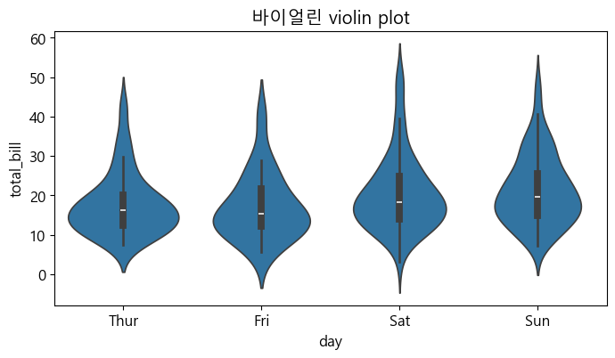

```python
sns.violinplot(x="day", y="total_bill", data=tips)
plt.title('바이얼린 violin plot')
plt.show()
```

```python
tips['day'].value_counts()
```

```
day
Sat     87
Sun     76
Thur    62
Fri     19
Name: count, dtype: int64
```

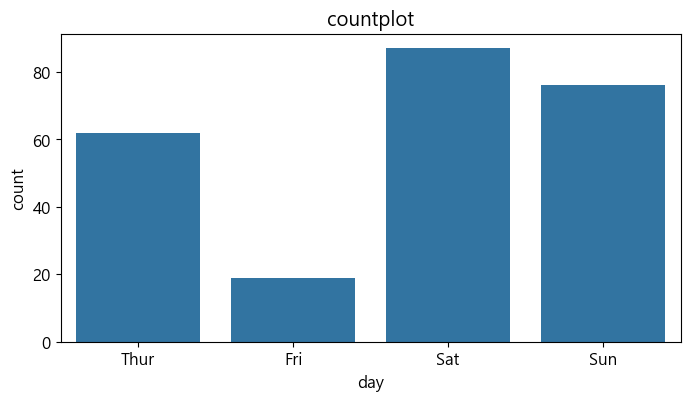

```python
sns.countplot(x=tips['day'])
plt.title('countplot')
plt.show()
```

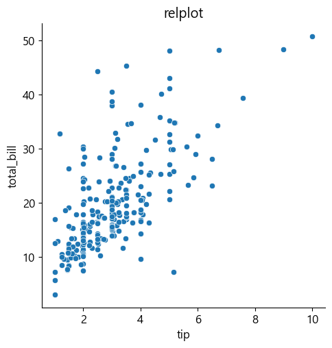

```python
sns.relplot(x='tip', y='total_bill', data=tips)
plt.title('relplot')
plt.show()
```

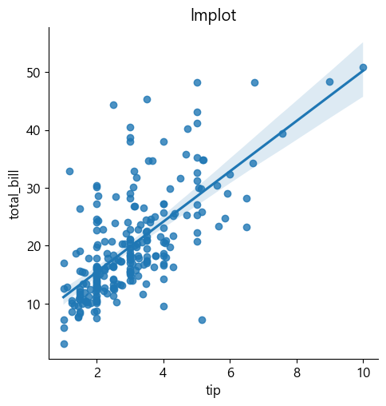

```python
sns.lmplot(x='tip', y='total_bill', data=tips)
plt.title('lmplot')
plt.show()
```

```python
file_path = "datas/sns_tips.csv"
tips = pd.read_csv(file_path)
tips
```

|  | total_bill | tip | gender | smoker | day | time | size |
| --- | --- | --- | --- | --- | --- | --- | --- |
| 0 | 16.99 | 1.01 | Female | No | Sun | Dinner | 2 |
| 1 | 10.34 | 1.66 | Male | No | Sun | Dinner | 3 |
| 2 | 21.01 | 3.50 | Male | No | Sun | Dinner | 3 |
| 3 | 23.68 | 3.31 | Male | No | Sun | Dinner | 2 |
| 4 | 24.59 | 3.61 | Female | No | Sun | Dinner | 4 |
| ... | ... | ... | ... | ... | ... | ... | ... |
| 239 | 29.03 | 5.92 | Male | No | Sat | Dinner | 3 |
| 240 | 27.18 | 2.00 | Female | Yes | Sat | Dinner | 2 |
| 241 | 22.67 | 2.00 | Male | Yes | Sat | Dinner | 2 |
| 242 | 17.82 | 1.75 | Male | No | Sat | Dinner | 2 |
| 243 | 18.78 | 3.00 | Female | No | Thur | Dinner | 2 |

244 rows × 7 columns

```python
 tips.info()
```

```
<class 'pandas.core.frame.DataFrame'>
RangeIndex: 244 entries, 0 to 243
Data columns (total 7 columns):
 #   Column      Non-Null Count  Dtype
---  ------      --------------  -----
 0   total_bill  244 non-null    float64
 1   tip         244 non-null    float64
 2   gender      244 non-null    object
 3   smoker      244 non-null    object
 4   day         244 non-null    object
 5   time        244 non-null    object
 6   size        244 non-null    int64
dtypes: float64(2), int64(1), object(4)
memory usage: 13.5+ KB
```

### 0-2. 아름다운 스타일링

seaborn의 최대 장점 중 하나인, 아름다운 컬러팔레트

`matplotlib`의 기본 컬러 색상보다 `seaborn`은 스타일링에 크게 신경을 쓰지 않아도 **default 컬러가 예쁘게 조합** 됨

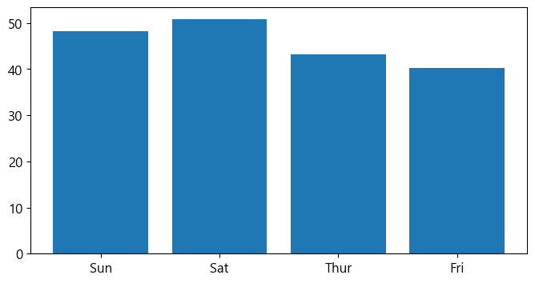

```python
plt.bar(tips['day'], tips['total_bill'])
plt.show()
```

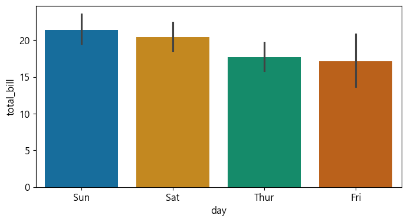

```python
sns.barplot(x="day", y="total_bill", data=tips, palette='colorblind')
plt.show()
```

### 0-3. 컬러 팔레트

자세한 컬러팔레트는 **공식 도큐먼트** 참고

[Seaborn의 컬러팔레트](http://seaborn.pydata.org/tutorial/color_palettes.html?highlight=sns+palplot)

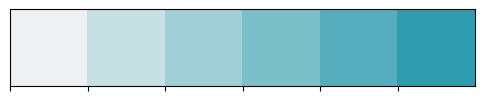

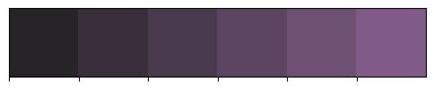

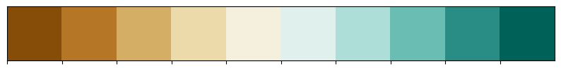

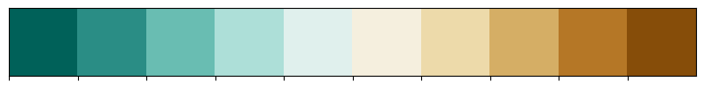

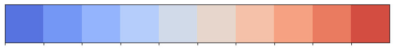

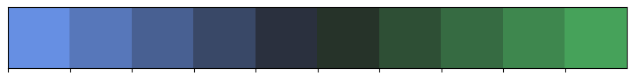

```python
sns.palplot(sns.light_palette((210, 90, 60), input="husl"))
sns.palplot(sns.dark_palette("muted purple", input="xkcd"))
sns.palplot(sns.color_palette("BrBG", 10))
sns.palplot(sns.color_palette("BrBG_r", 10))
sns.palplot(sns.color_palette("coolwarm", 10))
sns.palplot(sns.diverging_palette(255, 133, l=60, n=10, center="dark"))
```

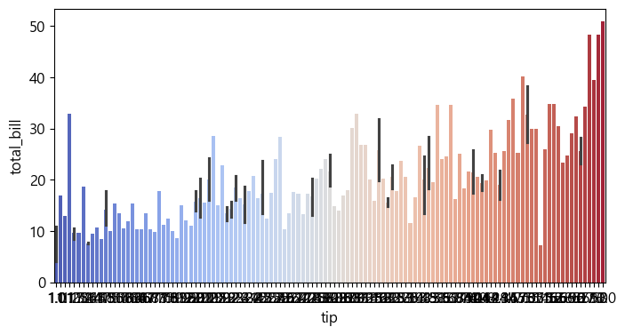

```python
sns.barplot(x="tip", y="total_bill", data=tips, palette='coolwarm')
```

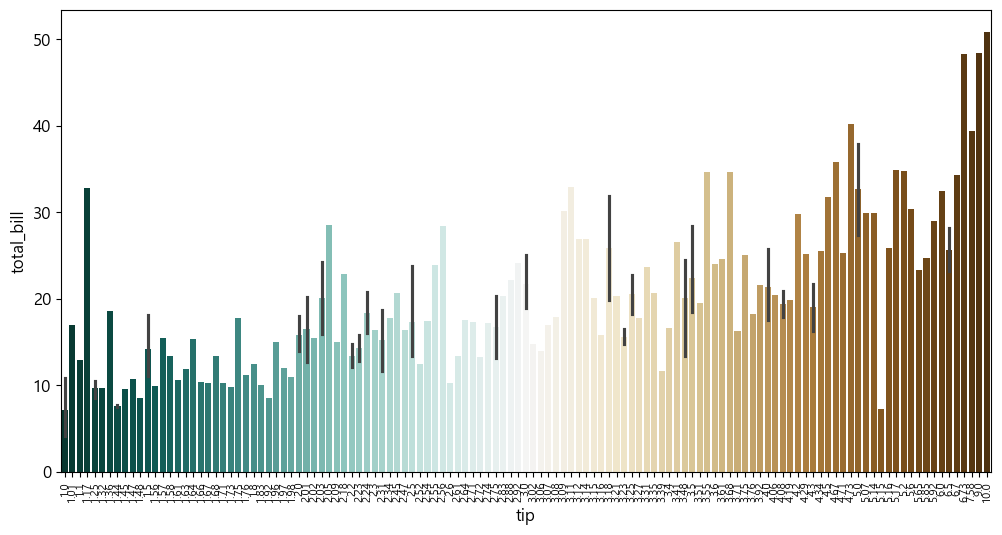

```python
plt.figure(figsize=(12, 6))

sns.barplot(x="tip", y="total_bill", data=tips, palette='BrBG_r')
# x축 틱 레이블 각도 변경
plt.xticks(rotation=90, fontsize=8)
plt.show()
```

### 0-4. pandas 데이터프레임과 높은 호환성

```python
tips
```

|  | total_bill | tip | gender | smoker | day | time | size |
| --- | --- | --- | --- | --- | --- | --- | --- |
| 0 | 16.99 | 1.01 | Female | No | Sun | Dinner | 2 |
| 1 | 10.34 | 1.66 | Male | No | Sun | Dinner | 3 |
| 2 | 21.01 | 3.50 | Male | No | Sun | Dinner | 3 |
| 3 | 23.68 | 3.31 | Male | No | Sun | Dinner | 2 |
| 4 | 24.59 | 3.61 | Female | No | Sun | Dinner | 4 |
| ... | ... | ... | ... | ... | ... | ... | ... |
| 239 | 29.03 | 5.92 | Male | No | Sat | Dinner | 3 |
| 240 | 27.18 | 2.00 | Female | Yes | Sat | Dinner | 2 |
| 241 | 22.67 | 2.00 | Male | Yes | Sat | Dinner | 2 |
| 242 | 17.82 | 1.75 | Male | No | Sat | Dinner | 2 |
| 243 | 18.78 | 3.00 | Female | No | Thur | Dinner | 2 |

244 rows × 7 columns

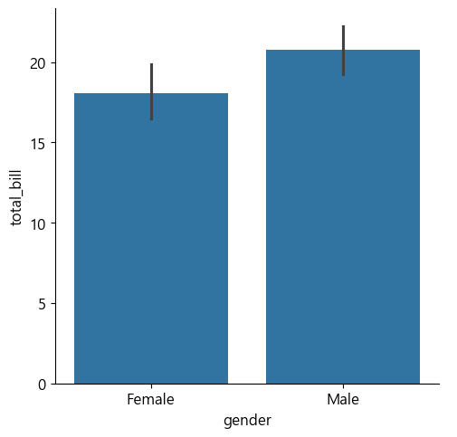

```python
sns.catplot(x="gender", y="total_bill",
            data=tips,
            kind="bar")
plt.show()
```

`hue` 옵션으로 bar를 구분

- xtick, ytick, xlabel, ylabel을 알아서 생성해 줌
- legend 까지 자동으로 생성함
- 신뢰 구간도 알아서 계산하여 생성

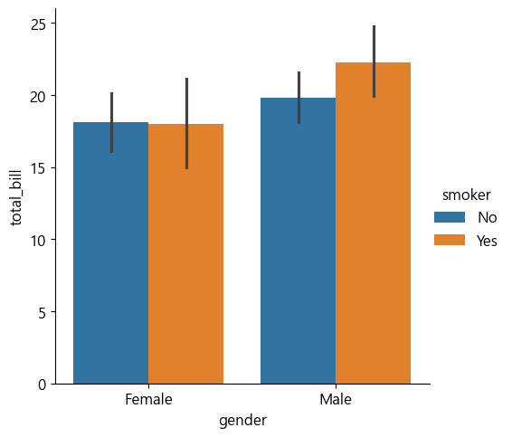

```python
sns.catplot(x="gender", y="total_bill",
            hue="smoker",
            data=tips,
            kind="bar")
plt.show()
```

`col`옵션 하나로 그래프 자체를 분할해 줌

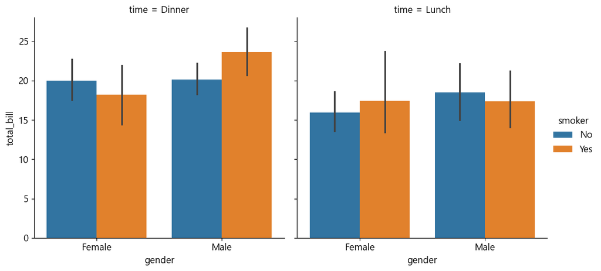

```python
sns.catplot(x="gender", y="total_bill",
            hue="smoker",
            col="time",
            data=tips,
            kind="bar")
plt.show()
```

### 상관관계 계수 heatmap 시각화

- heatmap으로 시각화할 대상 컬럼은 모두 숫자로 되어있어야함.
- 상관관계 계수를 적용하기 범주형 데이터를 숫자로 변경하기
- 피어슨상관계수 참고 https://sunnyyanolza.tistory.com/42

### [문제] 범주형 데이터를 label로 인코딩하기

- 범주형 데이터 컬럼을 찾기
- 범주형 컬럽의 values 확인
- 범주형 values -> 숫자로 변환

```python
import pandas as pd
import seaborn as sns
# 데이터 준비
file_path = "datas/sns_tips.csv"
tips = pd.read_csv(file_path)
tips.head()
```

|  | total_bill | tip | gender | smoker | day | time | size |
| --- | --- | --- | --- | --- | --- | --- | --- |
| 0 | 16.99 | 1.01 | Female | No | Sun | Dinner | 2 |
| 1 | 10.34 | 1.66 | Male | No | Sun | Dinner | 3 |
| 2 | 21.01 | 3.50 | Male | No | Sun | Dinner | 3 |
| 3 | 23.68 | 3.31 | Male | No | Sun | Dinner | 2 |
| 4 | 24.59 | 3.61 | Female | No | Sun | Dinner | 4 |

```python
# 범주형 데이터 확인하기
tips.select_dtypes(include='object').columns
```

```
Index(['gender', 'smoker', 'day', 'time'], dtype='object')
```

```python
# gender 컬럼의 값 확인
tips['gender'].value_counts().sort_index()
```

```
gender
Female     87
Male      157
Name: count, dtype: int64
```

```python
# mapping 컬럼 mapping 코드 만들기
gen_map={
    'Female': 0,
    'Male': 1
}
```

```python
# smoker 컬럼의 값 확인
tips['smoker'].value_counts().sort_index()
```

```
smoker
No     151
Yes     93
Name: count, dtype: int64
```

```python
# smoker 컬럼 mapping 코드 만들기
smo_map={
    'No': 0,
    'Yes': 1
}
```

```python
# day 컬럼의 값 확인
tips['day'].value_counts().sort_index()
```

```
day
Fri     19
Sat     87
Sun     76
Thur    62
Name: count, dtype: int64
```

```python
# day 컬럼 mapping 코드 만들기
day_map={
    'Fri': 0,
    'Thur': 1,
    'Sat': 2,
    'Sun': 3
}
```

```python
tips['time'].value_counts().sort_index()
```

```
time
Dinner    176
Lunch      68
Name: count, dtype: int64
```

```python
time_map={
    'Dinner': 0,
    'Lunch': 1
}
```

```python
# 범주형 데이터인 'gender', 'smoker', 'day', 'time' 열에 레이블 인코딩 적용
tips['gender'] = tips['gender'].map(gen_map)
tips['smoker'] =  tips['smoker'].map(smo_map)
tips['day'] = tips['day'].map(day_map)
tips['time'] = tips['time'].map(time_map)
```

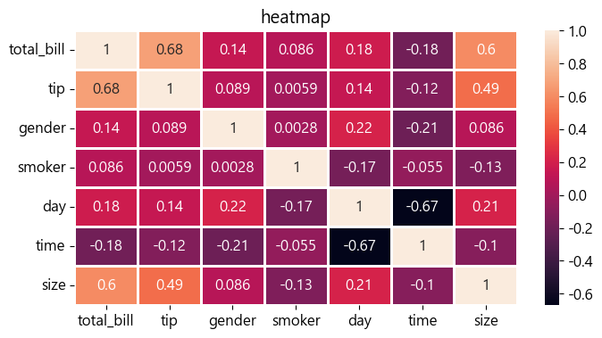

```python
plt.title('heatmap')
sns.heatmap(tips.corr(), annot=True, linewidths=1)
plt.show()
```

- data: 히트맵을 그릴 데이터셋, 2차원 배열 형태의 데이터를 입력받음
- annot: 히트맵 셀에 숫자 값을 표시할지 여부를 나타내는 부울값 또는 데이터 배열, 기본값은 False로 숫자 값이 표시되지 않음
- fmt: annot이 True로 설정된 경우 숫자 형식을 지정함, 예를 들어 ".2f"는 소수점 이하 2자리까지 표시하도록 지정함
- cmap: 히트맵의 색상 맵 지정, 예를 들어 "coolwarm", "viridis", "RdYlBu" 등 다양한 색상 맵을 사용할 수 있음
  - viridis: 영역별로 색상이 연속적으로 변화하는 색상 맵
  - plasma: 연속적인 분홍색과 청록색을 갖는 색상 맵
  - inferno: 연속적인 주황색과 검은색을 갖는 색상 맵
  - magma: 연속적인 검은색과 청록색을 갖는 색상 맵입
  - coolwarm: 차가운 색상과 따뜻한 색상이 교대로 나타나는 색상 맵
  - RdBu: 붉은색과 청록색이 교대로 나타나는 색상 맵
  - YlGnBu: 노란색, 녹색, 청록색, 파란색이 연속적으로 변화하는 색상 맵
- linewidths: 히트맵 셀 사이의 경계선 두께 지정
- linecolor: 히트맵 셀 사이의 경계선 색상을 지정
- cbar: 컬러바를 표시할지 여부를 나타내는 부울값임. 기본값은 True로 컬러바가 표시됨
- vmin, vmax : 컬러바의 범위 지정

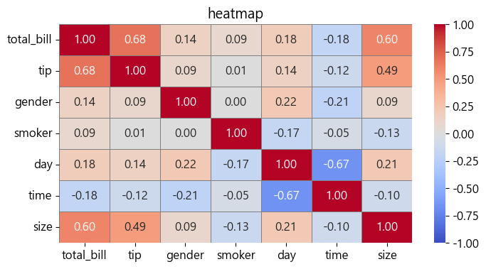

```python
plt.title('heatmap')
sns.heatmap(tips.corr(),
            annot=True,
            fmt=".2f",
            cmap="coolwarm",
            linewidths=0.5,
            linecolor="gray",
            cbar=True,
            vmin=-1,
            vmax=1
           )
plt.show()
```

## 1. Scatterplot

#### 데이터 준비

0 ~ 1 사이의 임의의 랜덤한 값을 생성함

```python
np.random.rand(50)
```

```
array([0.64234919, 0.88311482, 0.12051167, 0.56750374, 0.92478371,
       0.20440895, 0.66274747, 0.01778899, 0.11683833, 0.93706513,
       0.15726116, 0.77730216, 0.92099687, 0.79141942, 0.24552859,
       0.52351912, 0.68270065, 0.65273802, 0.47410332, 0.77207708,
       0.87198771, 0.47032014, 0.33009643, 0.23696305, 0.50711903,
       0.83683955, 0.85181382, 0.27819071, 0.28168072, 0.80734516,
       0.21811998, 0.00386372, 0.39827352, 0.39733284, 0.34852071,
       0.19838974, 0.4516391 , 0.00561328, 0.02812754, 0.20956943,
       0.07535887, 0.14098278, 0.55411391, 0.24293928, 0.32532782,
       0.06942235, 0.51251943, 0.06893164, 0.01200969, 0.84207171])
```

0 부터 50개의 값을 순차적으로 생성합니다.

```python
np.arange(50)
```

```
array([ 0,  1,  2,  3,  4,  5,  6,  7,  8,  9, 10, 11, 12, 13, 14, 15, 16,
       17, 18, 19, 20, 21, 22, 23, 24, 25, 26, 27, 28, 29, 30, 31, 32, 33,
       34, 35, 36, 37, 38, 39, 40, 41, 42, 43, 44, 45, 46, 47, 48, 49])
```

### 1-1. x, y, colors, area 설정하기

- colors 는 임의 값을 color 값으로 변환합니다.
- area는 점의 넓이를 나타냅니다. 값이 커지면 당연히 넓이도 커집니다.

```python
x = np.random.rand(50)
y = np.random.rand(50)
colors = np.arange(50)
area = x * y * 1000
```

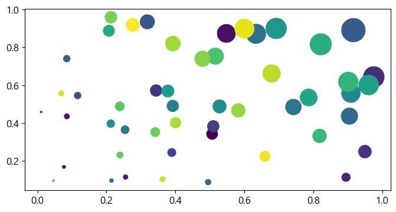

```python
# matplotlib의 산점도 그래프
plt.scatter(x, y, s=area, c=colors)
plt.show()
```

- seaborn 에서는 `size`와 `sizes`를 동시에 지정할 수 있음
- `sizes` 옵션에서는 사이즈의 min, max를 명시함
- `hue`는 컬러 옵션임
- `palette`를 통해 seaborn이 제공하는 아름다운 palette 사용 가능
  - Set1, Set2, deep, muted, bright, pastel, dark, colorblind, rocket, viridis, plasma, inferno, cividis, coolwarm, RdBu, husl, gist_gray

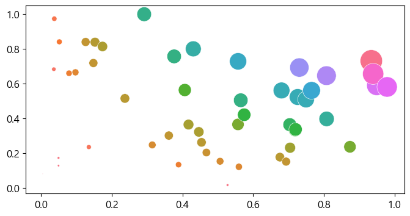

```python
import numpy as np
import seaborn as sns
import matplotlib.pyplot as plt

x = np.random.rand(50)
y = np.random.rand(50)
colors = np.arange(50)
area = x * y * 1000

sns.scatterplot(x=x, y=y, size=area, sizes=(area.min(), area.max()), hue=area, palette='husl', legend=False)
plt.show()
```

### tips 데이터를 활용한 산점도 시각화

```python
import seaborn as sns

# Sample dataset
file_path = "datas/sns_tips.csv"
tips = pd.read_csv(file_path)
```

#### "total_bill"과 "tip" 간의 관계를 시각화

- 식당에서 총 지불한 금액과 팁 금액간의 관계와 금액 분포 시각화

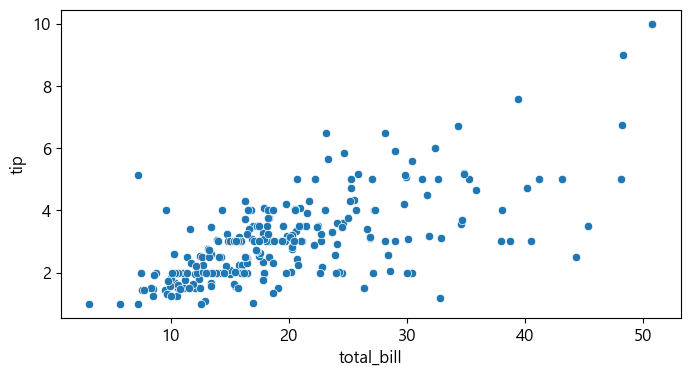

```python
sns.scatterplot(data=tips, x="total_bill", y="tip")

# 그래프 출력
plt.show()
```

[설명]

- 지불 금액이 높을수록 팁도 증가하는 경향을 보임
- 식당의 total_bill이 10 ~ 30사이에 많이 분포하고, 팀은 1~5사이에 많이 분포한다는 것을 알 수 있음

```python
tips.head()
```

|  | total_bill | tip | gender | smoker | day | time | size |
| --- | --- | --- | --- | --- | --- | --- | --- |
| 0 | 16.99 | 1.01 | Female | No | Sun | Dinner | 2 |
| 1 | 10.34 | 1.66 | Male | No | Sun | Dinner | 3 |
| 2 | 21.01 | 3.50 | Male | No | Sun | Dinner | 3 |
| 3 | 23.68 | 3.31 | Male | No | Sun | Dinner | 2 |
| 4 | 24.59 | 3.61 | Female | No | Sun | Dinner | 4 |

- 지불 금액과 팁 사이의 관계를 시간, 성별, 그리고 식사 인원 수와 같은 추가적인 요인에 따라 시각화
- 각 요소 간의 관계 파악하기

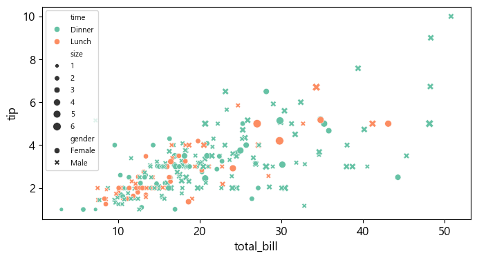

```python
# Scatter plot :
sns.scatterplot(data=tips, x="total_bill", y="tip", hue="time", style="gender", size="size", palette="Set2")

# legend 사이즈
plt.legend(prop={'size': 8})
# Display the plot
plt.show()
```

[설명]

- "total_bill"과 "tip" 간의 관계: 일반적으로 지불 금액이 높을수록 팁도 커지는 경향이 있음
- "time"(점심, 저녁)에 따른 분류:
  - 식사 시간 Dinner와 Lunch 시간에 따라 "total_bill"과 "tip"의 관계가 다른 것을 알 수 있음
  - 점심과 저녁 시간대에서의 팁의 분포가 다름
  - 저녁 시간일 수록 지불금액과 팁이 높아지는 경향성이 있음
- "gender"(남,여)에 따른 분류
  - 토탈 지불금액이 커질 수록 남자들이 좀더 많은 팁을 지불함
  - 남자들이 좀더 높을 금액의 total_bill을 지불하고, 그에 따른 높은 팁을 주는 경향이 있음
- "size"(식사인원수)에 따른 분류:
  - 포인트의 크기는 식사 인원 수
  - "size"에 따라"total_bill"과 "tip"의 관계가 다른 것을 확인할 수 있음
  - 인원 수가 많을수록 지불 금액과 팁의 크기가 증가함.

### 1-2. 다중 그래프 그리기

- 1개의 canvas 안 여러개 그래프 그리기
- alpha
  - alpha값은 투명도를 나타냄
  - 0 ~ 1 사이의 값 지정
  - 0에 가까울 수록 투명한 값을 가짐

```python
import numpy as np
import seaborn as sns
import matplotlib.pyplot as plt

x = np.random.rand(50)
y = np.random.rand(50)
colors = np.arange(50)
area = x * y * 1000
```

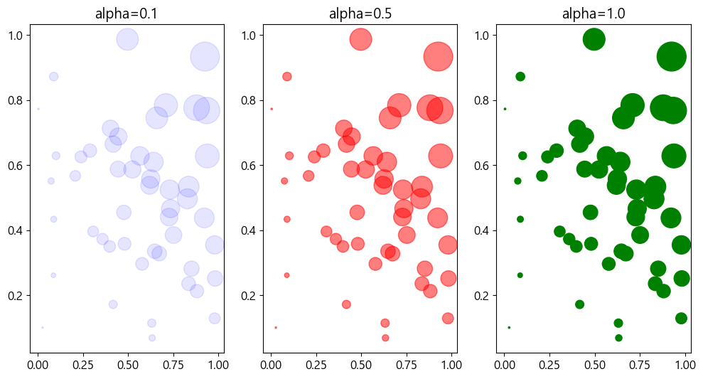

```python
#  matplotlib subplot 산점도
plt.figure(figsize=(12, 6))

plt.subplot(131)
plt.scatter(x, y, s=area, c='blue', alpha=0.1)
plt.title('alpha=0.1')
plt.subplot(132)
plt.title('alpha=0.5')
plt.scatter(x, y, s=area, c='red', alpha=0.5)
plt.subplot(133)
plt.title('alpha=1.0')
plt.scatter(x, y, s=area, c='green', alpha=1.0)

plt.show()
```

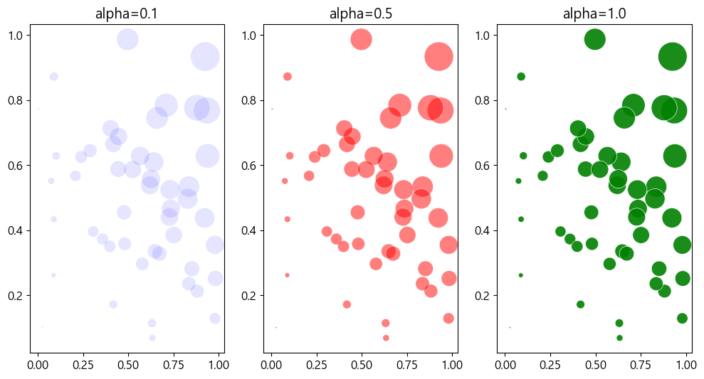

```python
# seaborn으로 subplot 산점도 그래프
plt.figure(figsize=(12, 6))

plt.subplot(131)
sns.scatterplot(x=x, y=y, size=area, sizes=(area.min(), area.max()), color='blue', alpha=0.1, legend=False)
plt.title('alpha=0.1')

plt.subplot(132)
plt.title('alpha=0.5')
sns.scatterplot(x=x, y=y, size=area, sizes=(area.min(), area.max()), color='red', alpha=0.5, legend=False)

plt.subplot(133)
plt.title('alpha=1.0')
sns.scatterplot(x=x, y=y, size=area, sizes=(area.min(), area.max()), color='green', alpha=0.9, legend=False)

plt.show()
```

## 2. Barplot, Barhplot

### 2-1. 기본 Barplot 그리기

#### matplotlib bar 차트 그리기

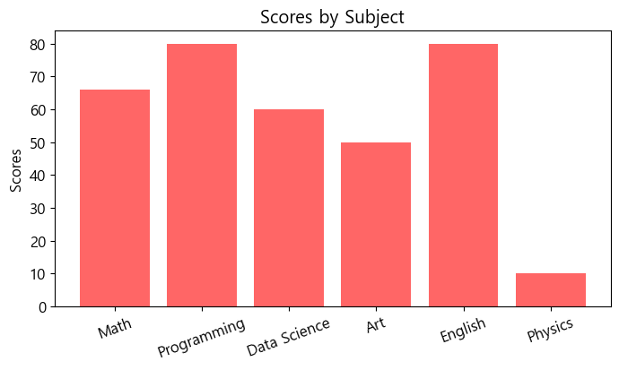

```python
subject = ['Math', 'Programming', 'Data Science', 'Art', 'English', 'Physics']
score = [66, 80, 60, 50, 80, 10]

plt.bar(subject, score, align='center', alpha=0.6, color='red')

plt.xticks(rotation=20)
plt.ylabel('Scores')
plt.title('Scores by Subject')

plt.show()
```

#### seaborn으로 bar 차트 그리기

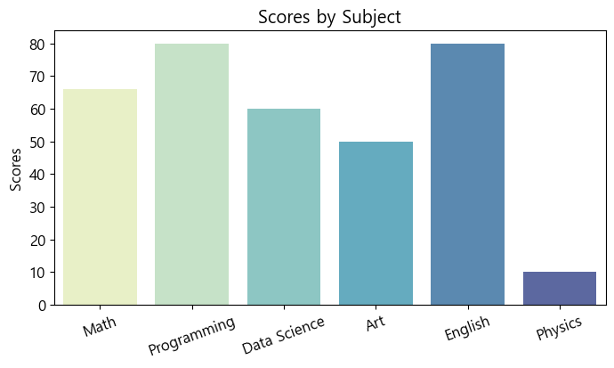

```python
subject = ['Math', 'Programming', 'Data Science', 'Art', 'English', 'Physics']
score = [66, 80, 60, 50, 80, 10]

sns.barplot(x=subject, y=score, alpha=0.8, palette='YlGnBu')

plt.xticks(rotation=20)
plt.ylabel('Scores')
plt.title('Scores by Subject')

plt.show()
```

### 2-2. 기본 Barhplot 그리기

barh 함수에서는 **xticks로 설정**했던 부분을 **yticks로 변경**합니다.

#### matplotlib으로 barh 차트 그리기

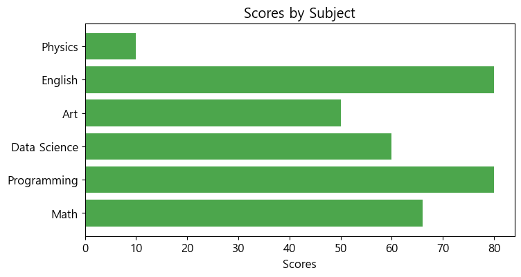

```python
subject = ['Math', 'Programming', 'Data Science', 'Art', 'English', 'Physics']
score = [66, 80, 60, 50, 80, 10]

plt.barh(subject, score, align='center', alpha=0.7, color='green')
plt.xlabel('Scores')
plt.title('Scores by Subject')

plt.show()
```

#### seaborn으로 barh 차트 그리기

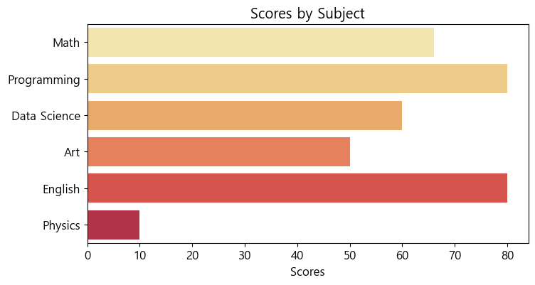

```python
subject = ['Math', 'Programming', 'Data Science', 'Art', 'English', 'Physics']
score = [66, 80, 60, 50, 80, 10]

# x, y 축 대입값을 바꿔서 표현
sns.barplot(x=score, y=subject, alpha=0.9, palette='YlOrRd')

plt.xlabel('Scores')
plt.title('Scores by Subject')

plt.show()
```

#### 차트 결과 높은 값 순으로 표시하기

##### 방법1. 리스트를 소팅하여 차트 적용

```python
subject = ['Math', 'Programming', 'Data Science', 'Art', 'English', 'Physics']
score = [66, 80, 60, 50, 80, 10]

# 방법1 데이터를 내림차순으로 정렬, key=정렬 기준
data = sorted(zip(subject, score), key=lambda x: x[1], reverse=True)
data
```

```
[('Programming', 80),
 ('English', 80),
 ('Math', 66),
 ('Data Science', 60),
 ('Art', 50),
 ('Physics', 10)]
```

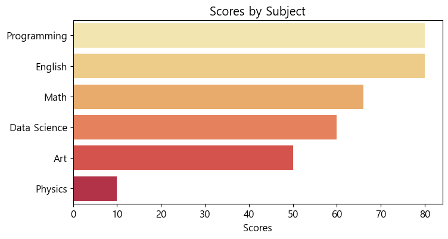

```python
subject_s = [item[0] for item in data]
score_s = [item[1] for item in data]

# x, y 축 대입값을 바꿔서 표현
sns.barplot(x=score_s, y=subject_s, alpha=0.9, palette='YlOrRd')

plt.xlabel('Scores')
plt.title('Scores by Subject')

plt.show()
```

##### 방법2. dataframe로 만들어 소팅하여 적용

```python
subject = ['Math', 'Programming', 'Data Science', 'Art', 'English', 'Physics']
score = [66, 80, 60, 50, 80, 10]
df = pd.DataFrame(zip(subject, score), columns=['subject', 'score'])
df
```

|  | subject | score |
| --- | --- | --- |
| 0 | Math | 66 |
| 1 | Programming | 80 |
| 2 | Data Science | 60 |
| 3 | Art | 50 |
| 4 | English | 80 |
| 5 | Physics | 10 |

```python
df = df.sort_values('score', ascending=False)
df
```

|  | subject | score |
| --- | --- | --- |
| 1 | Programming | 80 |
| 4 | English | 80 |
| 0 | Math | 66 |
| 2 | Data Science | 60 |
| 3 | Art | 50 |
| 5 | Physics | 10 |

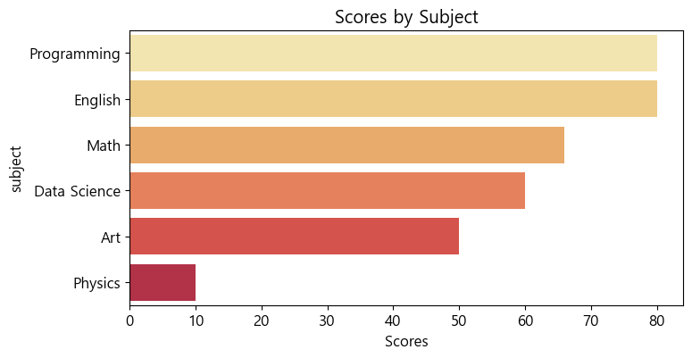

```python
# x, y 축 대입값을 바꿔서 표현
sns.barplot(x=df['score'], y=df['subject'], alpha=0.9, palette='YlOrRd')

plt.xlabel('Scores')
plt.title('Scores by Subject')

plt.show()
```

### 2-3 Barplot 비교 그래프 그리기

#### 두 학생의 과목별 성적 비교하기

**axes.bar(x, height, width=0.8, bottom=None, align='center', **kwargs)**

- x: 막대 그래프의 x 좌표. 보통은 범주 혹은 카테고리의 값들을 의미함
- height: 막대의 높이를 지정하는 값, 보통은 해당 범주에 대한 데이터 값이 사용
- width (선택적): 막대의 너비를 지정하는 값. 기본값은 0.8임
- bottom (선택적): 막대의 시작 위치를 지정하는 값. 기본적으로 막대는 0부터 시작
- align (선택적): 막대의 정렬 방식을 지정하는 값.
  - 'center', 'edge' 또는 'align' 중 하나를 선택
  - 기본값은 'center'
- **kwargs: 기타 추가적인 옵션들을 지정할 수 있는 매개변수
  - 예를 들어, 색상, 투명도, 라벨 등을 설정할 수 있음

```python
import numpy as np
import seaborn as sns
import matplotlib.pyplot as plt
```

```python
subject = ['Math', 'Programming', 'Data Science', 'Art', 'English', 'Physics']
score1 = [66, 80, 60, 50, 80, 10]
score2 = [55, 90, 40, 60, 70, 20]

# subject 갯수 만큼 숫자리스트 생성(0~5)
sj_num = np.arange(len(subject))
```

```python
sj_num-0.4/2
```

```
array([-0.2,  0.8,  1.8,  2.8,  3.8,  4.8])
```

```python
# 넓이 지정, default=0.8
width = 0.4
sj_num + width/2
```

```
array([0.2, 1.2, 2.2, 3.2, 4.2, 5.2])
```

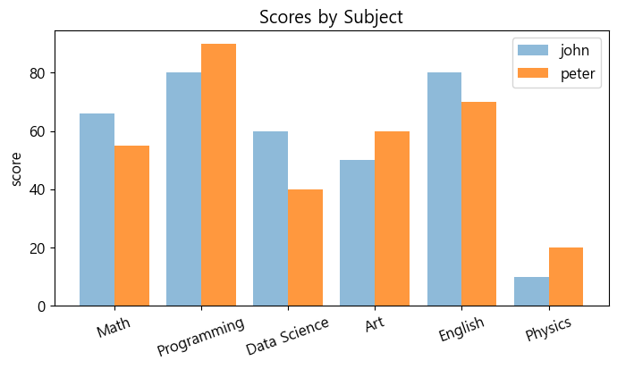

```python
# 넓이 지정, default=0.8
width = 0.4

# subplots 생성
fig, axes = plt.subplots()

# 막대 그래프를 생성하는 역할
# axes.bar(x좌표, height, width=0.8, bottom=None, align='center', **kwargs)
axes.bar(sj_num - width/2, score1, width, align='center', alpha=0.5)
axes.bar(sj_num + width/2, score2, width, align='center', alpha=0.8)

# xtick 설정
axes.set_xticks(sj_num)
axes.set_xticklabels(subject)

plt.ylabel('score')
plt.title('Scores by Subject')

plt.xticks(rotation=20)
plt.legend(['john', 'peter'])

plt.show()
```